# Data Checks

Pandemic PACT Funding Tracker Dataset

Authors

Affiliation

Proochista Ariana

Centre for Tropical Medicine and Global Health, Nuffield Department of Medicine, University of Oxford

Ernest Guevarra

Centre for Tropical Medicine and Global Health, Nuffield Department of Medicine, University of Oxford

Published

September 28, 2024

## Summary

We found the following issues in the dataset downloaded from the Pandemic PACT website.

**Critical issues**

**Consider addressing**

4. One-to-one correspondence between fields/variables that are linked to each other (e.g., country and region, category and subcategory, priority and subpriority) is inconsistent particularly on records with multiple responses/values.
5. Confusing and often incoherent use of `"Not applicable"`, `"Unspecified"`, `"N/A"`, and `""` throughout the dataset.

## Introduction

This document reports on basic data checks performed on the Pandemic PACT tracker dataset available from its [website](https://www.pandemicpact.org). Each section of the document is an assessment for each field/variable found in the downloaded dataset from the website. We used the available functions in the [`{pactr}`](https://oxford-ihtm.io/pactr) package to read and check the dataset.

```r
## Read dataset from website ----
pact_data <- pact_read_website()
```

### Purpose

The purpose of this report is to document the structure, form, and details of the dataset available from the Pandemic PACT website and note challenges and issues from a data handling and wrangling perspective and also possible errors. This report is aimed at those wanting to directly work with the downloadable dataset from the Pandemic PACT website and perform their own exploratory analysis and/or use the dataset for their respective research as a guide to handling the data in an analysis platform or software.

### Reproducibility

This review was conducted using [R](https://r-project.org) language for statistical computing and graphics. Literate code that produced this report can be found by clicking on the code icon on the upper right corner of this document. Reproducible code of the scientific workflow that produced this report can be found [here](https://github.com/OxfordIHTM/pandemic-pact-research). For full reproducibility, please use and follow the instructions in this [repository](https://github.com/OxfordIHTM/pandemic-pact-research) for the scientific workflow.

This report uses data from the Pandemic PACT website downloaded on the day of report publication shown above.

## Data checks

### GrantID

**Note**

- **NA** NAs/missing values
- **NA** duplicated values

### PubMedGrantId

**Note**

- a grant may have more than one PubMedGrantId and the different values for pubmed ID are separated by a *comma* or a *space*
- **80** records had a *comma* separator
- **173** records had a *space* separator
- **NA** NA values…
- …but there are **62** records with empty value (““) - should these be NAs?
- there are **435** pub med grant ids that have been converted to exponential format - might be due to conversion during processing especially if Excel spreadsheet was used for processing

### GrantTitleEng

**Note**

- **NA** NA values
- **NA** empty values
- no obvious issues noted

### Abstract

**Note**

- **6** records with NA values…
- … and **960** more records with empty (`""`) values - should these just be treated as NAs?

### PublicationYearOfAward

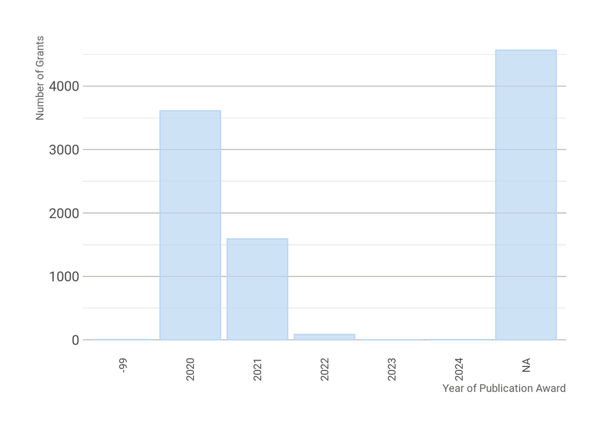

Figure 1: Distribution of grant publication year values

```r
pact_data |> dplyr::count(PublicationYearOfAward)
```

Table 1: Grant publication year values

| PublicationYearOfAward | n |
| --- | --- |
| -99 | 3 |
| 2020 | 3612 |
| 2021 | 1591 |
| 2022 | 84 |
| 2023 | 1 |
| 2024 | 4 |
|  | 4567 |

**Note**

- there are **4567** NA values;
- there are **0** empty (`""`) values;
- there are **3** `-99` values; should these be recoded to NA?

### GrantEndYear

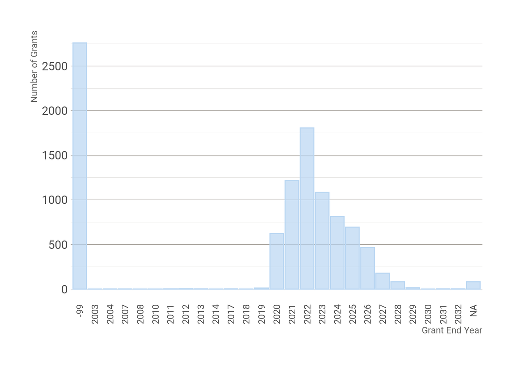

Figure 2: Distribution of grant end year values

```r
pact_data |> dplyr::count(GrantEndYear)
```

Table 2: Grant end year values

| GrantEndYear | n |
| --- | --- |
| -99 | 2759 |
| 2003 | 1 |
| 2004 | 2 |
| 2007 | 2 |
| 2008 | 1 |
| 2010 | 1 |
| 2011 | 3 |
| 2012 | 4 |
| 2013 | 3 |
| 2014 | 1 |

[output cut: 17 more lines]

**Note**

- there are **82** NA values;
- there are **0** empty (““) values;
- there are **2759** `-99` values; should these be recoded to NA?

### ResearchInstitutionName

```r
pact_data |> dplyr::count(ResearchInstitutionName)
```

Table 3: Names of research institutions

| ResearchInstitutionName | n |
| --- | --- |
| 2rLAB DEASS SUPSI | 1 |
| 2tainment GmbH | 1 |
| 3a-diagnostics GmbH | 1 |
| 3pc GmbH Neue Kommunikation | 1 |
| 4YouandMe | 1 |
| ?mura Satoshi Memorial Institute, Kitasato University | 1 |
| A C Camargo Cancer Center. Fundação Antonio Prudente (FAP) | 1 |
| A&amp;O-fonds Provincies | 1 |
| AARHUS UNIVERSITET | 1 |
| ABALOS THERAPEUTICS GmbH | 1 |

[output cut: 3307 more lines]

**Note**

- there are **0** NA values;
- there are **939** `"N/A"` values - should these be recoded to NA?

### GrantAmountConverted

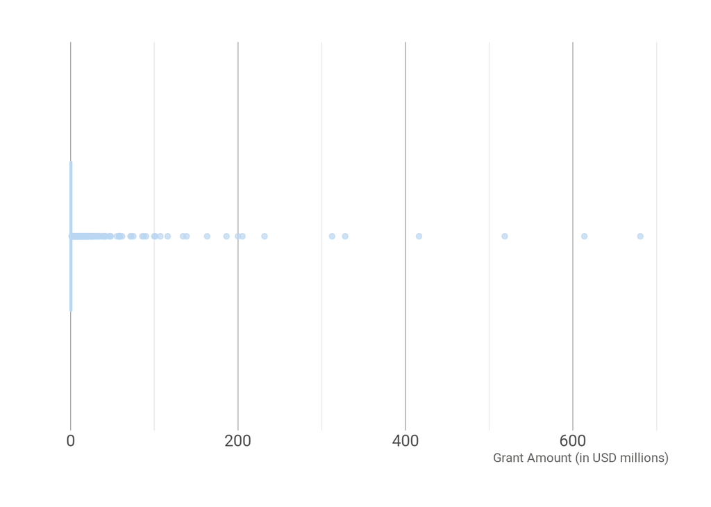

Figure 3: Distribution of grant amounts - full range

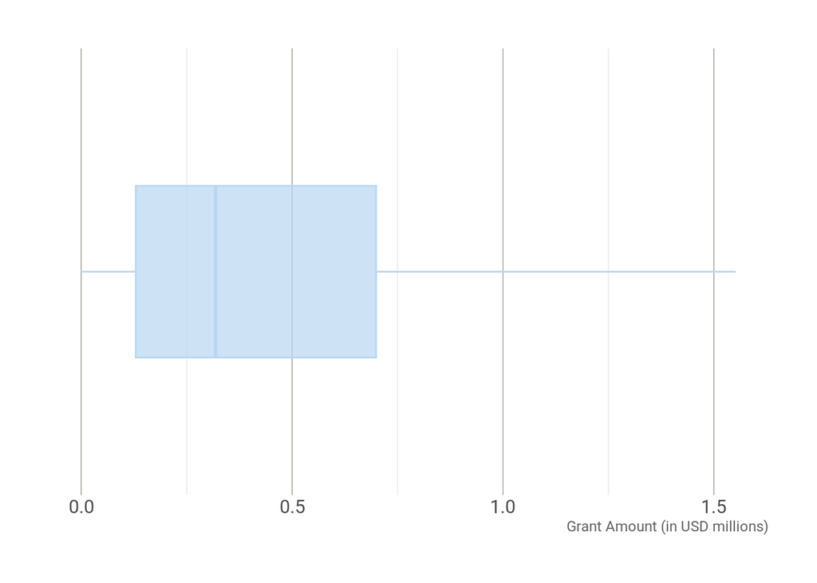

Figure 4: Distribution of grant amounts - without outliers

**Note**

- there are **1426** NA values

### StudySubject

```r
pact_data |> dplyr::count(StudySubject)
```

Table 4: Study subject values

| StudySubject | n |
| --- | --- |
| Animals | 390 |
| Animals \| Bacteria | 9 |
| Animals \| Bacteria \| Disease Vectors \| Viruses | 1 |
| Animals \| Bacteria \| Environment | 1 |
| Animals \| Disease Vectors | 2 |
| Animals \| Disease Vectors \| Viruses | 2 |
| Animals \| Environment | 5 |
| Animals \| Human Populations | 82 |
| Animals \| Human Populations \| Disease Vectors | 13 |
| Animals \| Human Populations \| Disease Vectors \| Environment | 1 |

[output cut: 44 more lines]

**Note**

- a grant may have more than one StudySubject value; different values are separated by a `" | "`; there are **951** records with more than one StudySubject values
- there are **0** NA values;
- there are **0** empty (`""`) values;
- there are **178** values of StudySubject that contain “Not applicable” of which **4** are one of multiple values for a grant record - this seems incorrect as how can the same grant have an StudySubject value and then also be not applicable? If we take not applicable as NA, this will not matter but it is an incoherent record for this variable.

### Ethnicity

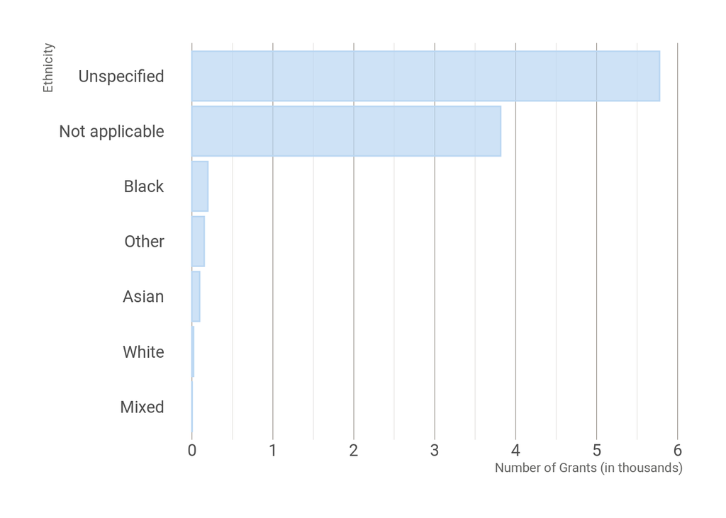

Figure 5: Distribution of ethnicity values

```r
pact_data |> dplyr::count(Ethnicity)
```

Table 5: Ethnicity values

| Ethnicity | n |
| --- | --- |
| Asian | 50 |
| Asian \| Black | 10 |
| Asian \| Black \| Other | 16 |
| Asian \| Black \| Other \| Unspecified | 4 |
| Asian \| Black \| Unspecified | 2 |
| Asian \| Black \| White | 2 |
| Asian \| Black \| White \| Mixed | 1 |
| Asian \| Black \| White \| Unspecified | 1 |
| Asian \| Other | 3 |
| Asian \| Unspecified | 4 |

[output cut: 19 more lines]

**Note**

- a grant may have more than one Ethnicity value; different values are separated by a `" | "`; there are **150** records with more then one value for Ethnicity
- there are **0** NA values
- there are **0** empty (`""`) values
- there are **3814** values of Ethnicity that contain “Not applicable” of which **41** are one of multiple values for a grant record - this seems incorrect as how can the same grant have an Ethnicity value and then also be not applicable? If we take not applicable as NA, this will not matter but it is an incoherent record for this variable.
- there are **5777** values of Ethnicity that contain “Unspecified” of which **70** are one of multiple values for a grant record - this seems incorrect as how can the same grant have an AgeGroup value and then also be unspecified?

### AgeGroups

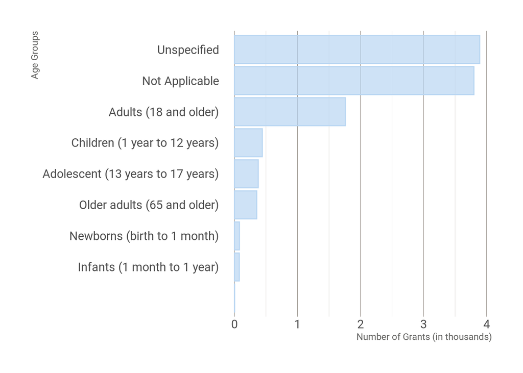

Figure 6: Distribution of age group values

```r
pact_data |> dplyr::count(AgeGroups)
```

Table 6: Age group values

| AgeGroups | n |
| --- | --- |
|  | 3 |
| Adolescent (13 years to 17 years) | 112 |
| Adolescent (13 years to 17 years) \| Adults (18 and older) | 89 |
| Adolescent (13 years to 17 years) \| Adults (18 and older) \| Children (1 year to 12 years) | 39 |
| Adolescent (13 years to 17 years) \| Adults (18 and older) \| Children (1 year to 12 years) \| Infants (1 month to 1 year) | 1 |
| Adolescent (13 years to 17 years) \| Adults (18 and older) \| Children (1 year to 12 years) \| Infants (1 month to 1 year) \| Newborns (birth to 1 month) | 3 |
| Adolescent (13 years to 17 years) \| Adults (18 and older) \| Children (1 year to 12 years) \| Infants (1 month to 1 year) \| Newborns (birth to 1 month) \| Older adults (65 and older) | 1 |
| Adolescent (13 years to 17 years) \| Adults (18 and older) \| Children (1 year to 12 years) \| Newborns (birth to 1 month) \| Older adults (65 and older) | 1 |
| Adolescent (13 years to 17 years) \| Adults (18 and older) \| Children (1 year to 12 years) \| Older adults (65 and older) | 6 |
| Adolescent (13 years to 17 years) \| Adults (18 and older) \| Older adults (65 and older) | 33 |

[output cut: 32 more lines]

**Note**

- a grant may have more than one AgeGroups value; different values are separated by a `" | "`; there are **743** records with more than one AgeGroups value
- there are **0** NA values;
- there are **3** empty (`""`) values;
- there are **3800** values of AgeGroup that contain “Not applicable” of which **42** are one of multiple values for a grant record - this seems incorrect as how can the same grant have an AgeGroup value and then also be not applicable? If we take not applicable as NA, this will not matter but it is an incoherent record for this variable.
- note also that for this field/variable, “Not Applicable” is spelled with a capital `A` as compared to small letter `a` for “Not applicable” in other fields/variables.
- there are **3892** values of AgeGroup that contain “Unspecified” of which **59** are one of multiple values for a grant record - this seems incorrect as how can the same grant have an AgeGroup value and then also be unspecified?

### Rurality

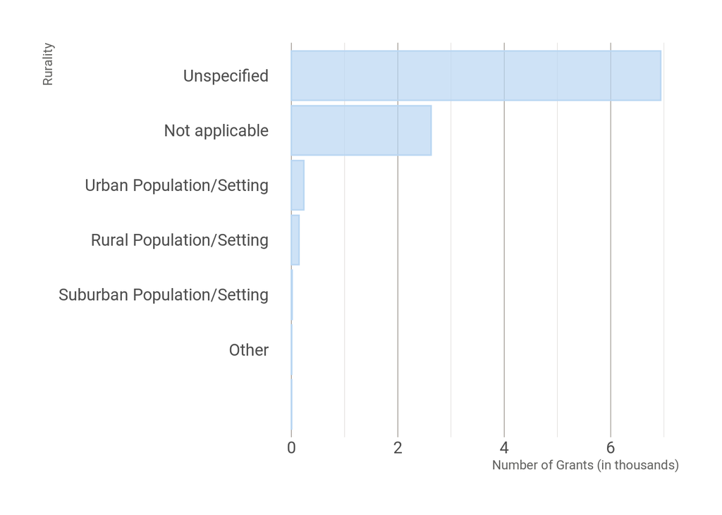

Figure 7: Distribution of rurality values

```r
pact_data |> dplyr::count(Rurality)
```

Table 7: Rurality values

| Rurality | n |
| --- | --- |
|  | 6 |
| Not applicable | 2594 |
| Other | 4 |
| Other \| Unspecified | 1 |
| Rural Population/Setting | 84 |
| Rural Population/Setting \| Suburban Population/Setting | 1 |
| Rural Population/Setting \| Suburban Population/Setting \| Urban Population/Setting | 7 |
| Rural Population/Setting \| Unspecified | 2 |
| Rural Population/Setting \| Urban Population/Setting | 50 |
| Suburban Population/Setting | 3 |

[output cut: 6 more lines]

**Note**

- a grant may have more than one Rurality value; different values are separated by a `" | "`; there are **101** records with more than one Rurality value
- there are **0** NA values;
- there are **6** empty (`""`) values;
- there are **2625** values of Rurality that contain “Not applicable” of which **31** are one of multiple values for a grant record - this seems incorrect as how can the same grant have an Rurality value and then also be not applicable? If we take not applicable as NA, this will not matter but it is an incoherent record for this variable.
- there are **6939** values of Rurality that contain “Unspecified” of which **37** are one of multiple values for a grant record - this seems incorrect as how can the same grant have a Rurality value and then also be unspecified?

### VulnerablePopulations

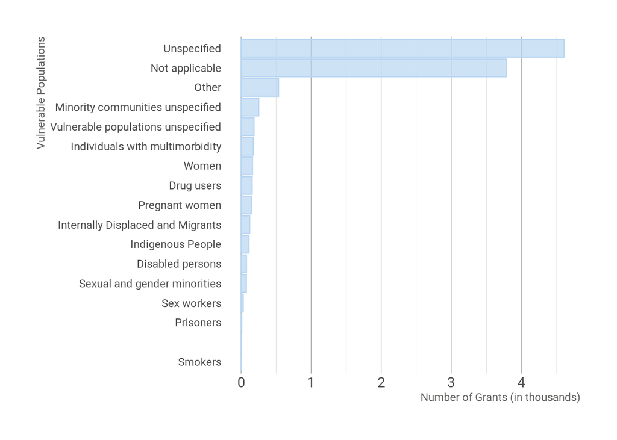

Figure 8: Distribution of vulnerable populations values

```r
pact_data |> dplyr::count(VulnerablePopulations)
```

Table 8: Vulnerable populations values

| VulnerablePopulations | n |
| --- | --- |
|  | 3 |
| Disabled persons | 53 |
| Disabled persons \| Indigenous People \| Sexual and gender minorities \| Minority communities unspecified | 2 |
| Disabled persons \| Individuals with multimorbidity | 2 |
| Disabled persons \| Individuals with multimorbidity \| Minority communities unspecified | 1 |
| Disabled persons \| Internally Displaced and Migrants \| Vulnerable populations unspecified | 1 |
| Disabled persons \| Internally Displaced and Migrants \| Vulnerable populations unspecified \| Other | 1 |
| Disabled persons \| Minority communities unspecified | 1 |
| Disabled persons \| Other | 9 |
| Disabled persons \| Sex workers \| Vulnerable populations unspecified | 1 |

[output cut: 111 more lines]

**Note**

- a grant may have more than one VulnerablePopulations value; different values are separated by a `" | "`; there are **490** records with more than one VulnerablePopulations value;
- there are **0** NA values;
- there are **3** empty (`""`) values;
- there are **3784** values of VulnerablePopulations that contain “Not applicable” of which **41** are one of multiple values for a grant record - this seems incorrect as how can the same grant have an VulnerablePopulations value and then also be not applicable? If we take not applicable as NA, this will not matter but it is an incoherent record for this variable.
- there are **4614** values of VulnerablePopulations that contain “Unspecified” of which **112** are one of multiple values for a grant record - this seems incorrect as how can the same grant have an VulnerablePopulations value and then also be unspecified?

### OccupationalGroups

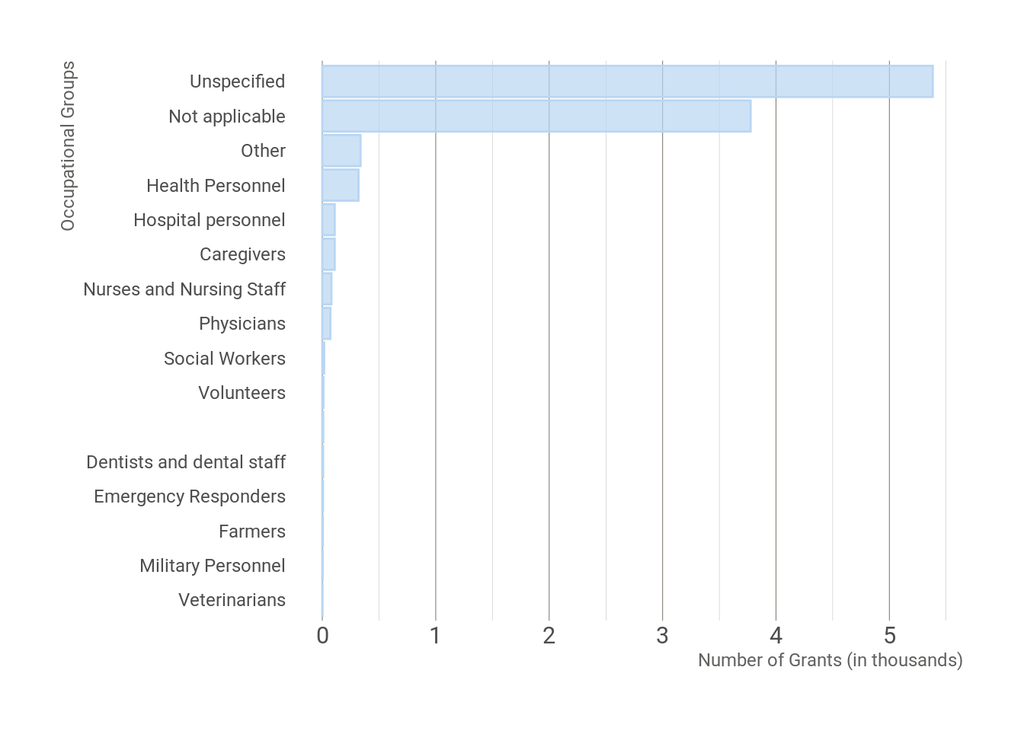

Figure 9: Distribution of occupational groups values

```r
pact_data |> dplyr::count(OccupationalGroups)
```

Table 9: Occupational groups values

| OccupationalGroups | n |
| --- | --- |
|  | 8 |
| Caregivers | 57 |
| Caregivers \| Health Personnel | 14 |
| Caregivers \| Health Personnel \| Hospital personnel | 1 |
| Caregivers \| Health Personnel \| Hospital personnel \| Nurses and Nursing Staff \| Physicians | 1 |
| Caregivers \| Health Personnel \| Physicians \| Other | 1 |
| Caregivers \| Health Personnel \| Unspecified | 2 |
| Caregivers \| Hospital personnel | 2 |
| Caregivers \| Hospital personnel \| Nurses and Nursing Staff | 1 |
| Caregivers \| Nurses and Nursing Staff | 4 |

[output cut: 69 more lines]

**Note**

- a grant may have more than one OccupationalGroups value; different values are separated by a `" | "`; there are **276** records with more than one OccupationalGroups value;
- there are **0** NA values;
- there are **8** empty (`""`) values;
- there are **3776** values of OccupationalGroups that contain “Not applicable” of which **40** are one of multiple values for a grant record - this seems incorrect as how can the same grant have an OccupationalGroups value and then also be not applicable? If we take not applicable as NA, this will not matter but it is an incoherent record for this variable.
- there are **5382** values of OccupationalGroups that contain “Unspecified” of which **93** are one of multiple values for a grant record - this seems incorrect as how can the same grant have an OccupationalGroups value and then also be unspecified?

### StudyType

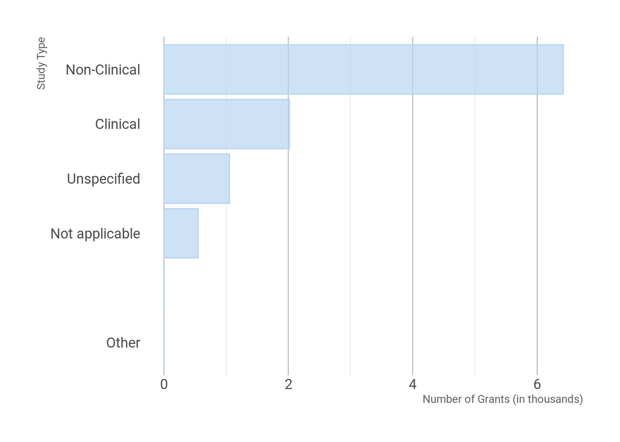

Figure 10: Distribution of study type values

```r
pact_data |> dplyr::count(StudyType)
```

Table 10: Study type values

| StudyType | n |
| --- | --- |
|  | 5 |
| Clinical | 1834 |
| Clinical \| Non-Clinical | 182 |
| Non-Clinical | 6235 |
| Non-Clinical \| Not applicable | 2 |
| Not applicable | 547 |
| Other | 3 |
| Unspecified | 1053 |
| Unspecified \| Not applicable | 1 |

**Note**

- a grant may have more than one StudyType value; different values are separated by a `" | "`; there are **185** records with more than one StudyType value;
- there are **0** NA values;
- there are **5** empty (`""`) values;
- there are **550** values of StudyType that contain “Not applicable” of which **3** are one of multiple values for a grant record - this seems incorrect as how can the same grant have a StudyType value and then also be not applicable? If we take not applicable as NA, this will not matter but it is an incoherent record for this variable.
- there are **1054** values of StudyType that contain “Unspecified” of which **1** are one of multiple values for a grant record - this seems incorrect as how can the same grant have a StudyType value and then also be unspecified?

### ClinicalTrial

- it would seem that this variable will only have a value if StudyType has “Clinical” as a response. To check this:

```r
pact_data |>
  dplyr::mutate(
    StudyTypeX = stringr::str_replace_all(
      StudyType, pattern = "Non-Clinical", replacement = "Non-clinical"
    ),
    grouping = stringr::str_detect(StudyTypeX, pattern = "Clinical")
  ) |>
  dplyr::group_by(grouping) |>
  dplyr::count(ClinicalTrial)
```

Table 11: Clinical trial values grouped by study type values

| grouping | ClinicalTrial | n |
| --- | --- | --- |
| False |  | 7714 |
| False | Not applicable | 81 |
| False | Unspecified | 51 |
| True |  | 14 |
| True | Clinical Trial, Phase I | 29 |
| True | Clinical Trial, Phase I \| Clinical Trial, Phase II | 22 |
| True | Clinical Trial, Phase I \| Clinical Trial, Phase II \| Clinical Trial, Phase III | 1 |
| True | Clinical Trial, Phase I \| Clinical Trial, Veterinary | 1 |
| True | Clinical Trial, Phase I \| Unspecified | 1 |
| True | Clinical Trial, Phase II | 44 |

[output cut: 16 more lines]

**Note**

- there are **0** NA values for records that are indicated as “Clinical” in StudyType;
- there are **14** empty (`""`) values for records that are indicated as “Clinical” in StudyType;
- for records that are indicated as “Clinical” in StudyType, there are **1258** values of ClinicalTrial that contain “Not applicable” of which **6** are one of multiple values for a grant record - this seems incorrect as how can the same grant have a ClinicalTrial value and then also be not applicable?
- for records that are indicated as “Clinical” in StudyType, there are **431** values of ClinicalTrial that contain “Unspecified” of which **7** are one of multiple values for a grant record - this seems incorrect as how can the same grant have a ClinicalTrial value and then also be unspecified?
- for records that are indicated as “Non-Clinical”, they have ClinicalTrial values of **, Not applicable, Unspecified**

### Pathogen

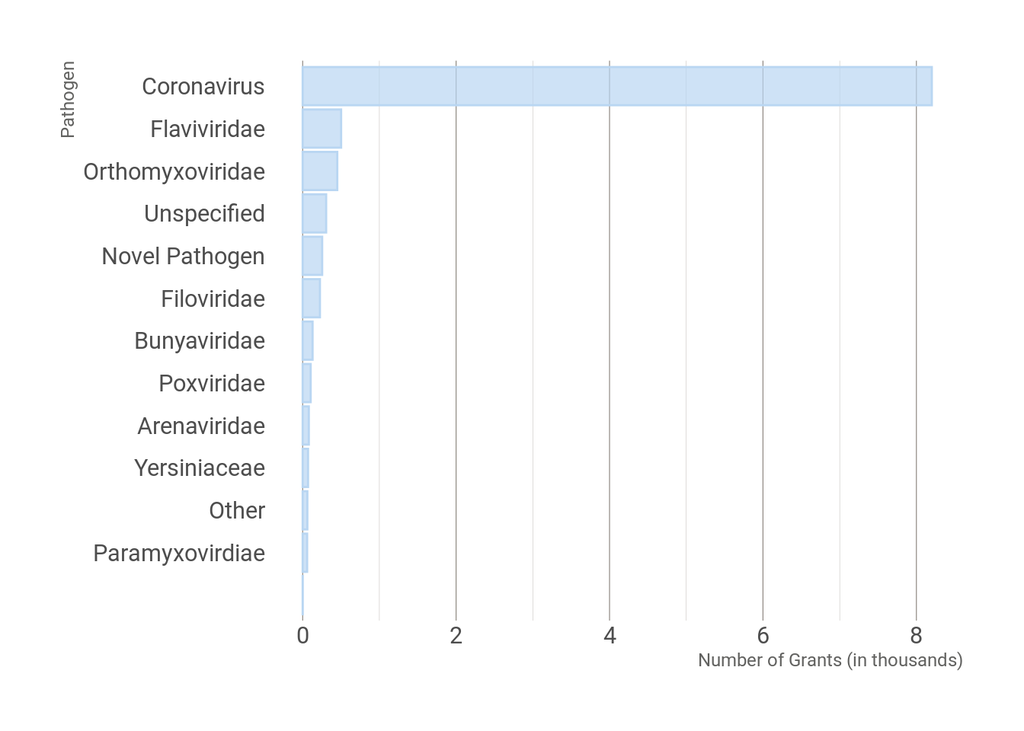

Figure 11: Distribution of pathogen values

```r
pact_data |> dplyr::count(Pathogen)
```

Table 12: Pathogen values

| n |
| --- |
| 9862 |

**Note**

### InfluenzaA

- it would seem that this variable is only relevant if the response/value to Pathogen includes the genus Orthomyxoviridae. To check this:

```r
pact_data |>
  dplyr::mutate(
    grouping = stringr::str_detect(Pathogen, pattern = "Orthomyxoviridae")
  ) |>
  dplyr::group_by(grouping) |>
  dplyr::count(InfluenzaA)
```

Table 13: Influenza A values grouped by Orthomyxoviridae response to pathogen

| grouping | InfluenzaA | n |
| --- | --- | --- |
| False |  | 9405 |
| False | Unspecified | 6 |
| True |  | 1 |
| True | H1 | 25 |
| True | H1 \| H2 \| H3 \| H5 \| H6 \| H7 \| H10 \| Other | 7 |
| True | H1 \| H2 \| H3 \| H5 \| H6 \| H7 \| H10 \| Other \| Unspecified | 1 |
| True | H1 \| H2 \| H5 \| H6 \| Other | 1 |
| True | H1 \| H3 | 4 |
| True | H1 \| H3 \| H5 | 1 |
| True | H1 \| H3 \| H5 \| Other | 1 |

[output cut: 16 more lines]

**Note**

### InfluenzaH1

**Note**

- it would seem that this variable is only relevant if the response/value to Pathogen includes Orthomyxoviridae and if the response in InfluenzaA includes H1
- with this logic, we expect NAs for records that do not have Orthomyxoviridae in the Pathogens response and no H1 in the InfluenaA response.
- when checking all Pathogens that have Orthomyxoviridae and InfluenzaA that have H1, this seems to map out as expected.

### Disease

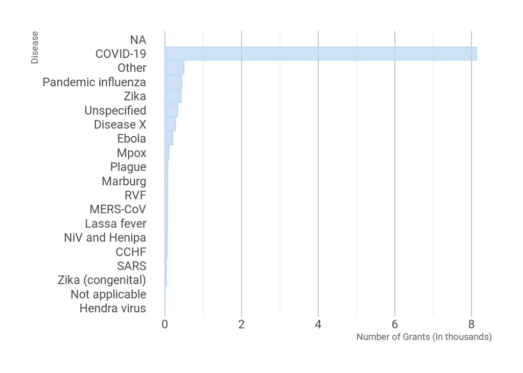

Figure 12: Distribution of disease values

```r
pact_data |> dplyr::count(Disease)
```

Table 14: Disease values

| Disease | n |
| --- | --- |
|  | 1 |
| COVID-19 | 7838 |
| COVID-19 \| Disease X | 50 |
| COVID-19 \| Disease X \| Unspecified | 2 |
| COVID-19 \| Ebola virus disease | 8 |
| COVID-19 \| Ebola virus disease \| Disease X | 1 |
| COVID-19 \| Ebola virus disease \| Disease X \| Other | 1 |
| COVID-19 \| Ebola virus disease \| Marburg virus disease | 1 |
| COVID-19 \| Ebola virus disease \| Marburg virus disease \| Unspecified | 1 |
| COVID-19 \| Ebola virus disease \| Other | 3 |

[output cut: 135 more lines]

**Note**

- there are **0** NA values;
- there are **1** empty (`""`) values;
- there are **7** values of Disease that contain “Not applicable” of which **1** are one of multiple values for a grant record - this seems incorrect as how can the same grant have a Disease value and then also be not applicable? If we take not applicable as NA, this will not matter but it is an incoherent record for this variable.
- there are **328** values of Disease that contain “Unspecified” of which **101** are one of multiple values for a grant record - this seems incorrect as how can the same grant have a Disease value and then also be unspecified?

### FundingOrgName

```r
pact_data |> dplyr::count(FundingOrgName)
```

Table 15: Funding organisation values

| FundingOrgName | n |
| --- | --- |
|  | 3 |
| 360biolabs \| Indian Council of Medical Research (ICMR) \| Novavax | 1 |
| African Academy of Sciences (AAS ) | 12 |
| Agence nationale de recherche sur le sida et les hépatites virale [National Agency for AIDS Research] (ANRS) | 42 |
| Agence nationale de recherche sur le sida et les hépatites virale [National Agency for AIDS Research] (ANRS) \| Expertise France | 1 |
| Alberta Innovates \| Canadian Institutes of Health Research (CIHR) | 10 |
| BC Ministry of Health \| Canadian Institutes of Health Research (CIHR) \| Michael Smith Foundation for Health Research | 1 |
| Bill &amp; Melinda Gates Foundation | 646 |
| Bill &amp; Melinda Gates Foundation \| COVID-19 Therapeutics Accelerator Wellcome Trust | 1 |
| Bill &amp; Melinda Gates Foundation \| Indian Council of Medical Research (ICMR) | 1 |

[output cut: 73 more lines]

**Note**

- there are **0** NA values;
- there are **3** empty (`""`) values;
- there are **0** values of FunderOrgName that contain “Not applicable”
- there are **0** values of FunderOrgName that contain “Unspecified”

### Funder Location

- Funder location information is provided in FunderCountry and FunderRegion. The protocol describes these fields/variables as:

> Funder name and country. The name of the funding organisation and information about their country of affiliation was checked against the CrossRef Open Funder Registry, and then entered in the database. We recorded information on multiple funders if the grant was funded by a joint funding scheme.

> Funder Region. We assigned each funder into one of the six WHO regions based on the funder country. We added international and unspecified values for those that fell outside of these regions.

#### FunderCountry and FunderRegion correspondence

- Based on this, we expect that given a country name for a funder, the corresponding WHO region will be provided in the region name. For multiple country locations, the region names should also show corresponding region names.
- From a database perspective, the expectation is that there is a one-to-one correspondence between country name and region name even with multiple responses.
- to check that there is one-to-one correspondence between FunderCountry and FunderRegion, we detect which rows of data have multiple responses and that the number of responses for FunderCountry is the same as FunderRegion:

```r
pact_data |>
  dplyr::filter(stringr::str_detect(FunderCountry, pattern = " \\| ")) |>
  dplyr::select(GrantID, FundingOrgName, FunderCountry, FunderRegion) |>
  dplyr::mutate(
    mismatch = pactr:::detect_mismatch(FunderCountry, FunderRegion)
  )
```

Table 16: Funder country and region mismatches

| GrantID | FundingOrgName | FunderCountry | FunderRegion | mismatch |
| --- | --- | --- | --- | --- |
| C01834 | Bill &amp; Melinda Gates Foundation \| COVID-19 Therapeutics Accelerator Wellcome Trust | United Kingdom \| United States of America | Americas \| Europe | False |
| C01843 | Bill &amp; Melinda Gates Foundation \| Wellcome Trust | United Kingdom \| United States of America | Americas \| Europe | False |
| C03633 | Research Council of Norway (RCN) \| Trond-Mohn Foundation | Norway \| United Kingdom | Europe | True |
| C03634 | Research Council of Norway (RCN) \| Trond-Mohn Foundation | Norway \| United Kingdom | Europe | True |
| C03635 | Research Council of Norway (RCN) \| Trond-Mohn Foundation | Norway \| United Kingdom | Europe | True |
| C03636 | Research Council of Norway (RCN) \| Trond-Mohn Foundation | Norway \| United Kingdom | Europe | True |
| C03637 | Research Council of Norway (RCN) \| Trond-Mohn Foundation | Norway \| United Kingdom | Europe | True |
| C03638 | Research Council of Norway (RCN) \| Trond-Mohn Foundation | Norway \| United Kingdom | Europe | True |
| C07720 | Canadian Institutes of Health Research (CIHR) \| Health Canada | Canada \| United Kingdom | Americas \| Europe | False |
| C07962 | National Natural Science Foundation of China (NSFC) \| National Research Foundation of Korea (NRF) | China \| South Korea | Western Pacific | True |

[output cut: 51 more lines]

**Note**

- For records that have a mismatch (`mismatch = TRUE`), all the countries in FunderCountry belong to the same region, so the dataset instead just records one value in FunderRegion. This is a non-problematic case for mismatches as there is still correct correspondence for FunderCountry to the appropriate FunderRegion.
- There are records (see record for **grant ID C07971**) where correspondence between country and region is important because the countries belong to different regions. In the example, even without a mismatch, it is not immediately machine-actionable to know which country matches with which region.
- However, switching our attention to those records that don’t have a mismatch:

Table 17: Funder country and region with no mismatches

| GrantID | FundingOrgName | FunderCountry | FunderRegion | mismatch |
| --- | --- | --- | --- | --- |
| C01834 | Bill &amp; Melinda Gates Foundation \| COVID-19 Therapeutics Accelerator Wellcome Trust | United Kingdom \| United States of America | Americas \| Europe | False |
| C01843 | Bill &amp; Melinda Gates Foundation \| Wellcome Trust | United Kingdom \| United States of America | Americas \| Europe | False |
| C07720 | Canadian Institutes of Health Research (CIHR) \| Health Canada | Canada \| United Kingdom | Americas \| Europe | False |
| C07971 | National Research Foundation of Korea (NRF) \| Swedish Research Council | South Korea \| Sweden | Europe \| Western Pacific | False |
| C07972 | National Research Foundation of Korea (NRF) \| Swedish Research Council | South Korea \| Sweden | Europe \| Western Pacific | False |
| C07973 | National Research Foundation of Korea (NRF) \| Swedish Research Council | South Korea \| Sweden | Europe \| Western Pacific | False |
| C07974 | National Research Foundation of Korea (NRF) \| Swedish Research Council | South Korea \| Sweden | Europe \| Western Pacific | False |
| C08227 | Foreign, Commonwealth &amp; Development Office (FCDO) \| Innovations for Poverty Action | United Kingdom \| International | Europe \| International | False |
| C08228 | Foreign, Commonwealth &amp; Development Office (FCDO) \| Innovations for Poverty Action | United Kingdom \| International | Europe \| International | False |
| C08229 | Foreign, Commonwealth &amp; Development Office (FCDO) \| Innovations for Poverty Action | United Kingdom \| International | Europe \| International | False |

[output cut: 36 more lines]

**Note**

Records for **Grant IDs C07971, C07972, C07973, C07974** show FunderCountry `South Korea | Sweden` with a corresponding FunderRegion of `Europe | Western Pacific`. Again, the values for FunderRegion are correct based on FunderCountry. However, the sequence of the values do not correspond to the sequence for FunderCountry. From a programming point of view, such exceptions to the what the structure of the data should be make the data less machine-actionable. As it is, the data can still be used to report on how many grants based on FunderRegion, and how many grants based on FunderCountry but given the structure, the data will not allow disaggregation by FunderRegion and then further disaggregated by FunderCountry per FunderRegion because of this loss of one-to-one correspondence. Some fixing and cleaning of the data will have to be done by the analyst to make that possible.

#### FunderCountry and FunderRegion agreement

- A more important check that needs to be routinely done on the location data other than the correspondence mentioned above is whether the classification of a country to the appropriate WHO region is being done correctly.
- For the records above that have more than one country, this is not an issue. The regional classification is correct albeit in some records not in one-to-one correspondence.
- For the rest of the records that only have one FunderCountry, we expect that the FunderRegion will also be a single value and that is the correct WHO regional classification. We check as follows:

```r
pact_data |>
  dplyr::filter(
    stringr::str_detect(FunderCountry, pattern = " \\| ", negate = TRUE)
  ) |>
  dplyr::select(GrantID, FundingOrgName, FunderCountry, FunderRegion) |>
  dplyr::mutate(
    region_check = pactr:::get_who_regions(FunderCountry),
    region_correct = FunderRegion == region_check
  ) |>
  dplyr::filter(!region_correct) |>
  dplyr::select(GrantID, FundingOrgName, FunderCountry, FunderRegion)
```

Table 18: Records with incorrect funder country and region classification

| GrantID | FundingOrgName | FunderCountry | FunderRegion |
| --- | --- | --- | --- |
| C10304 | Indian Council of Medical Research (ICMR) \| The Forum for Ethical Review Committees in the Asian and Western Pacific Region (FERCAP) | India | South-East Asia \| Western Pacific |

**Note**

- there are **1** records with incorrect FunderRegion information.

### Research Institution Location

- Research institution location information is provided in ResearchInstitutionCountry and ResearchInstitutionRegion. The protocol describes these fields/variables as:

> Institution name and institution country. We checked the names of all institutions and organisations that were awarded funding against the global standardised list of Research Organisation Registry (ROR)13, and entered the standardised name of the institution. Where no matches were found, for example, if the grant was given to non-research organisations, including private companies, the name was entered as provided in the grant. The country for research institution was assigned from the same global list. Then, the ISO code for the relevant country was recorded in the database.

> Institution region. We used the same approach for research institution, as for funding organisations. We assigned each research institution into one of the six WHO regions based on the institution country.

#### ResearchInstitutionCountry and ResearchInstitutionRegion correspondence

- Based on this, we expect that given a country name for a research institution, the corresponding WHO region will be provided in the region name. For multiple country locations, the region names should also show corresponding region names.
- From a database perspective, the expectation is that there is a one-to-one correspondence between country name and region name even with multiple responses.
- to check that there is one-to-one correspondence between ResearchInstitutionCountry and ResearchInstitutionRegion, we detect which rows of data have multiple responses and that the number of responses for ResearchInstitutionCountry is the same as ResearchInstitutionRegion:

```r
pact_data |>
  dplyr::filter(
    stringr::str_detect(ResearchInstitutionCountry, pattern = " \\| ")
  ) |>
  dplyr::select(
    GrantID, ResearchInstitutionName, ResearchInstitutionCountry, ResearchInstitutionRegion
  ) |>
  dplyr::mutate(
    mismatch = pactr:::detect_mismatch(
      ResearchInstitutionCountry, ResearchInstitutionRegion
    )
  )
```

Table 19: Research institution country and region mismatches

| GrantID | ResearchInstitutionName | ResearchInstitutionCountry | ResearchInstitutionRegion | mismatch |
| --- | --- | --- | --- | --- |
| C01121 | Economic and Social Research Council, Welsh Government, Cardiff University | United Kingdom \| United Kingdom \| United Kingdom | Europe | True |
| C01220 | Imperial College London, King's College London | United Kingdom \| United Kingdom | Europe | True |
| C01222 | Imperial College London, King's College London | United Kingdom \| United Kingdom | Europe | True |
| C01223 | Imperial College London, King's College London | United Kingdom \| United Kingdom | Europe | True |
| C01224 | Imperial College London, King's College London | United Kingdom \| United Kingdom | Europe | True |
| C01774 | Centre for the AIDS Programme of Research in South Africa | South Africa \| Denmark \| Germany \| Netherlands | Africa \| Europe | True |
| C01777 | London School of Hygiene &amp; Tropical Medicine | United Kingdom \| Ghana \| Spain | Africa \| Europe | True |
| C01788 | ZAMBART | Zambia \| France \| Netherlands \| United Kingdom | Africa \| Europe | True |
| C06122 | Leibniz Institute of Vegetable and Ornamental Crops, International Security and Development Center | Germany \| Germany | Europe | True |
| C06207 | London School of Hygiene &amp; Tropical Medicine, Universitas Gadjah Mada, Sebelas Maret University, UNSW Sydney, Ministry of Health, University of Indonesia, United States Agency for International De… | United Kingdom \| Indonesia \| Indonesia \| Australia \| Indonesia \| Indonesia \| Indonesia | Europe \| Western Pacific | True |

[output cut: 30 more lines]

**Note**

- For most of the records shown above, the regional classification is correct but not clear correspondence as to what country belongs to which region.
- Looking in more detail to the table, record with **Grant ID C06207** classify Indonesia as being in the Western Pacific region when in fact it is in the South-East Asia region.
- Switching our attention to those records that don’t have a mismatch:

Table 20: Research institution country and region with no mismatches

| GrantID | ResearchInstitutionName | ResearchInstitutionCountry | ResearchInstitutionRegion | mismatch |
| --- | --- | --- | --- | --- |
| C06384 | Ghana Health Service, Prins Leopold Instituut voor Tropische Geneeskunde, Organisation Ouest Africaine de la Santé | Ghana \| Belgium | Africa \| Europe | False |
| C15866 | Faculdade de Medicina - Universidade de SÇ?o Paulo (USP) | Italy \| Brazil | Americas \| Europe | False |

**Note**

- Both records with no mismatch have the right regions but not machine-actionable as it is unclear which region matches which country.

#### ResearchInstitutionCountry and ResearchInstitutionRegion agreement

- A more important check that needs to be routinely done on the location data other than the correspondence mentioned above is whether the classification of a country to the appropriate WHO region is being made.
- For the records above that have more than one country, this is not an issue. The regional classification is correct albeit in some records not in one-to-one correspondence.
- For the rest of the records that only have one ResearchInstitutionCountry, we expect that the ResearchInstitutionRegion will also be a single value and that it is the correct WHO regional classification. We check as follows:

```r
pact_data |>
  dplyr::filter(
    stringr::str_detect(
      ResearchInstitutionCountry, pattern = " \\| ", negate = TRUE
    )
  ) |>
  dplyr::select(
    GrantID, ResearchInstitutionName,
    ResearchInstitutionCountry, ResearchInstitutionRegion
  ) |>
  dplyr::mutate(
    region_check = pactr:::get_who_regions(ResearchInstitutionCountry),
    region_correct = ResearchInstitutionRegion == region_check
  ) |>
  dplyr::filter(!region_correct) |>
  dplyr::select(
    GrantID, ResearchInstitutionName,
    ResearchInstitutionCountry,
    ResearchInstitutionRegion
  )
```

Table 21: Records with incorrect institution country and institution region classification

| GrantID | ResearchInstitutionName | ResearchInstitutionCountry | ResearchInstitutionRegion |
| --- | --- | --- | --- |
| C00070 | University of British Columbia | Canada | Western Pacific |
| C00164 | University of Oxford | China | Europe |
| C01804 | Beth Israel Deaconess Medical Center | Israel | Eastern Mediterranean |
| C04119 | University of Portsmouth | Indonesia | Western Pacific |
| C06251 | MEMED DIAGNOSTICS LTD | Israel | Eastern Mediterranean |
| C13758 | University of St. Martin | Saint Martin (French part) | Americas |
| P21136 | Washington University | United States of America | Eastern Mediterranean |
| P21221 | Monash University | Australia | Americas |
| P21237 | University of Wisconsin-Madison | United States of America | Eastern Mediterranean |
| P22568 | UNIV OF SCIENCES, TECH &amp; TECH OF BAMAKO | Mali |  |

[output cut: 422 more lines]

**Note**

- there are **432** incorrect WHO regional classification based on ResearchInstitutionCountry

### Research Location

- Research location information is provided in ResearchLocationCountry and ResearchLoationRegion. The protocol describes these fields/variables as:

> Research Location Country and Region. We entered information where the research activities are taking place if information about the country, or a specific location, was different from the location of the research institution, and was provided in the grant abstract. Multiple locations were permitted, and relevant ISO codes for countries were used. The countries were then grouped into the six WHO regions. In no additional information on the research location was available, we used that of the research institution.

#### ResearchLocationCountry and ResearchLocationRegion correspondence

- Based on this, we expect that given a country name for a research institution, the corresponding WHO region will be provided in the region name. For multiple country locations, the region names should also show corresponding region names.
- From a database perspective, the expectation is that there is a one-to-one correspondence between country name and region name even with multiple responses.
- to check that there is one-to-one correspondence between ResearchInstitutionCountry and ResearchInstitutionRegion, we detect which rows of data have multiple responses and that the number of responses for ResearchInstitutionCountry is the same as ResearchInstitutionRegion:

```r
pact_data |>
  dplyr::filter(
    stringr::str_detect(ResearchLocationCountry, pattern = " \\| ")
  ) |>
  dplyr::select(
    GrantID,
    ResearchLocationCountry,
    ResearchLocationRegion
  ) |>
  dplyr::mutate(
    mismatch = pactr:::detect_mismatch(
      ResearchLocationCountry, ResearchLocationRegion
    )
  )
```

Table 22: Research location country and region mismatches

| GrantID | ResearchLocationCountry | ResearchLocationRegion | mismatch |
| --- | --- | --- | --- |
| C00038 | Canada \| China \| Viet Nam \| Spain \| Italy \| Mozambique \| Sudan \| Ethiopia \| Egypt \| Morocco \| Cote d'Ivoire | Africa \| Americas \| Europe \| Western Pacific | True |
| C00040 | China \| Pakistan \| Kenya | Africa \| Eastern Mediterranean \| Western Pacific | False |
| C00046 | Canada \| Netherlands | Americas \| Europe | False |
| C00047 | Canada \| United States of America | Americas | True |
| C00051 | Canada \| Singapore \| Brunei Darussalam \| Malaysia \| Thailand \| Philippines \| Indonesia \| Viet Nam \| Lao People's Democratic Republic \| Myanmar \| Cambodia | Americas \| South-East Asia \| Western Pacific | True |
| C00065 | Canada \| Philippines \| Sri Lanka | Americas \| South-East Asia \| Western Pacific | False |
| C00067 | Canada \| Kenya | Africa \| Americas | False |
| C00071 | Canada \| United Kingdom \| United States of America \| Kenya \| Rwanda | Africa \| Americas \| Europe | True |
| C00078 | Canada \| China | Americas \| Western Pacific | False |
| C00103 | United States of America \| Canada \| Australia \| Spain \| United Kingdom \| New Zealand \| Austria \| Belgium \| France \| Germany \| Hungary \| Israel \| Italy \| Latvia \| Lithuania \| Malta \| Po… | Americas \| Eastern Mediterranean \| Europe \| Western Pacific | True |

[output cut: 249 more lines]

**Note**

- For mismatches, it’s mainly the region not having one-to-one correspondence with the country.
- The record for **Grant ID C00038**, country shows multiple locations one of which is Egypt, but in region, there is no Eastern Mediterranean where Egypt is classified.
- Switching our attention to those records that don’t have a mismatch:

Table 23: Research location country and region with no mismatches

| GrantID | ResearchLocationCountry | ResearchLocationRegion | mismatch |
| --- | --- | --- | --- |
| C00040 | China \| Pakistan \| Kenya | Africa \| Eastern Mediterranean \| Western Pacific | False |
| C00046 | Canada \| Netherlands | Americas \| Europe | False |
| C00065 | Canada \| Philippines \| Sri Lanka | Americas \| South-East Asia \| Western Pacific | False |
| C00067 | Canada \| Kenya | Africa \| Americas | False |
| C00078 | Canada \| China | Americas \| Western Pacific | False |
| C00108 | Canada \| China | Americas \| Western Pacific | False |
| C00128 | Canada \| China | Americas \| Western Pacific | False |
| C00130 | Canada \| China | Americas \| Western Pacific | False |
| C00140 | Canada \| China | Americas \| Western Pacific | False |
| C00150 | Canada \| China | Americas \| Western Pacific | False |

[output cut: 83 more lines]

**Note**

#### ResearchLocationCountry and ResearchLocationRegion agreement

- A more important check that needs to be routinely done on the location data other than the correspondence mentioned above is whether the classification of a country to the appropriate WHO region is being made.
- For the records above that have more than one country, this is not an issue. The regional classification is correct albeit in some records not in one-to-one correspondence.
- For the rest of the records that only have one ResearchInstitutionCountry, we expect that the ResearchInstitutionRegion will also be a single value and that it is the correct WHO regional classification. We check as follows:

```r
pact_data |>
  dplyr::filter(
    stringr::str_detect(
      ResearchLocationCountry, pattern = " \\| ", negate = TRUE
    )
  ) |>
  dplyr::select(
    GrantID,
    ResearchLocationCountry,
    ResearchLocationRegion
  ) |>
  dplyr::mutate(
    region_check = pactr:::get_who_regions(ResearchLocationCountry),
    region_correct = ResearchLocationRegion == region_check
  ) |>
  dplyr::filter(!region_correct) |>
  dplyr::select(
    GrantID,
    ResearchLocationCountry,
    ResearchLocationRegion
  )
```

Table 24: Records with incorrect research location country and institution region classification

| GrantID | ResearchLocationCountry | ResearchLocationRegion |
| --- | --- | --- |
| C01030 | Egypt | Africa |
| C01031 | Lao People's Democratic Republic | South-East Asia |
| C01040 | Tunisia | Africa |
| C04119 | Indonesia | Western Pacific |
| C06207 | Indonesia | Western Pacific |
| C06251 | Israel | Eastern Mediterranean |
| C07393 | Indonesia | Western Pacific |
| C11508 | Sudan | Africa |
| C19469 | Lao People's Democratic Republic | South-East Asia |

**Note**

- There are **9** records that have misclassified ResearchLocationRegion based on their ResearchLocationCountry.